# Comment Author Analysis

Dan Snow

6/3/2019

First, we load the non-aggregated, labelled data created by our Jupyter Notebooks. This data contains the author, date, subreddit, sentiment, classification, and combined score.

```r
# Load and concat all of the raw CSV data
files <- list.files(path="../data/analysis", pattern="*.csv", full.names = T)
comments <- do.call(bind_rows, map(files, read_csv))
glimpse(comments)
```

[output not shown]

Next, we filter and aggregate our data by author. The `data/authors_filter.csv` set is the result passing the list of all authors in `comments` to `queries/06_get_author_counts_bq.sql`. It contains the aggregate number of posts each author has made in the pre-treatment period, as well as the number of posts they’ve made in The_Donald. An author is considered “treated” if they have posted in The_Donald more than 5 times and more than 20 times overall in the pre-treatment period. Control posters are kept in the dataset if they have posted more than 20 times overall in the pre-treatment period, otherwise they are filtered out.

```r
# Load a list of authors with more than 20 posts + more than 5 posts in The_Donald
authors_filter <- read_csv("../data/authors_filter.csv")
authors_treatment <- authors_filter %>%
  filter(count >= 20 & td_count >= 5) %>%
  pull(author)

# Load a list of active (more than 20 posts) authors
authors_active <- authors_filter %>%
  filter(count >= 20) %>%
  pull(author)

# Filter the overall comments set to keep only active authors
comments_active <- comments %>%
  filter(author %in% authors_active)

# Create an author set between the caliper dates with labelled treatment authors
authors_prematch <- get_author_prematch(
  comments_active,
  authors = authors_treatment,
  caliper_date = "2016-05-01",
  treat_date = "2016-11-01"
)

# Remove bots and low activity authors
authors_prematch_filtered <- authors_prematch %>%
  filter(between(count, 5, 500))

# Perform matching to determine a valid set of treatment and controls
# WARNING: VERY SLOW
match.out <- matchit(
  treated ~ mean_hate,
  method = "nearest",
  data = authors_prematch_filtered)

authors_matched <- as_tibble(match.data(match.out))

authors_matched %>%
  write_csv("../data/authors_matched_v2.csv")
```

```r
# Get the aggregated data for all authors
authors <- get_author_stats(comments_active, authors = authors_treatment)

# Keep only authors in the matched control and treatment groups
# set the POST var to a hard cutoff at 2017-02-15, the day The_Donald
# stopped being on the front page
authors_final_sharp <- authors %>%
  filter(author %in% authors_matched$author) %>%
  mutate(post = if_else(date >= ymd("2017-02-15"), 1, 0)) %>%
  write_csv("../data/authors_final_sharp_data.csv")

# Same as above, but exclude all posts within the "treatment window"
authors_final_fuzzy <- authors %>%
  filter(author %in% authors_matched$author) %>%
  mutate(post = if_else(date >= ymd("2017-02-15"), 1, 0)) %>%
  filter(!between(date, ymd("2016-11-15"), ymd("2017-02-15"))) %>%
    write_csv("../data/authors_final_fuzzy_data.csv")
```

Finally, we run the regression using our filtered, matched data for authors with different calipers.

```r
# Sharp treatment period with 6 month caliper
models_sharp <- read_csv("../data/authors_final_sharp_data.csv") %>%
  get_caliper("2016-08-01", "2017-09-01")

stargazer(
  models_sharp[1], models_sharp[2], models_sharp[3], models_sharp[4],
  title = "DiD Hate Speech (Sharp)",
  type = "text",
  font.size = "large",
  column.labels = c("NN + Vader", "NN Only"),
  column.separate = c(2, 2),
  dep.var.labels = c("Prop.", "Cnt.", "Prop.", "Cnt."),
  dep.var.caption = "Treatment Effect on Hate Speech"
  )
```

```
##
## DiD Hate Speech (Sharp)
## =================================================================================
##                                           Treatment Effect on Hate Speech
##                                   -----------------------------------------------
##                                     Prop.       Cnt.       Prop.         Cnt.
##                                        NN + Vader                NN Only
##                                      (1)        (2)         (3)          (4)
## ---------------------------------------------------------------------------------
## treated                            0.017***   0.816***    0.109***     3.008***
##                                    (0.001)    (0.030)     (0.002)      (0.071)
##
## post                              -0.037***  -0.817***   -0.038***    -1.475***
##                                    (0.001)    (0.032)     (0.002)      (0.075)
##
## treated:post                       0.021***    -0.062    -0.011***    -1.028***
##                                    (0.001)    (0.045)     (0.002)      (0.106)
##
## Constant                           0.133***   2.583***    0.292***     5.951***
##                                    (0.001)    (0.021)     (0.001)      (0.050)
##
## ---------------------------------------------------------------------------------
## Observations                       182,293    182,293     182,293      182,293
## R2                                  0.016      0.015       0.052        0.021
## Adjusted R2                         0.016      0.015       0.052        0.021
## Residual Std. Error (df = 182289)   0.155      4.741       0.242        11.197
## F Statistic (df = 3; 182289)      966.046*** 902.082*** 3,318.633*** 1,294.928***
## =================================================================================
## Note:                                                 *p<0.1; **p<0.05; ***p<0.01
```

```r
# Fuzzy treatment period with 6 month caliper
models_fuzzy <- read_csv("../data/authors_final_fuzzy_data.csv") %>%
  get_caliper("2016-06-01", "2017-08-01")

stargazer(
  models_fuzzy,
  title = "DiD Hate Speech (Fuzzy)",
  type = "text",
  font.size = "large",
  column.labels = c("NN + Vader", "NN Only"),
  column.separate = c(2, 2),
  dep.var.labels = c("Prop.", "Cnt.", "Prop.", "Cnt."),
  dep.var.caption = "Treatment Effect on Hate Speech"
  )
```

```
##
## DiD Hate Speech (Fuzzy)
## ===================================================================================
##                                            Treatment Effect on Hate Speech
##                                   -------------------------------------------------
##                                      Prop.        Cnt.       Prop.         Cnt.
##                                         NN + Vader                 NN Only
##                                       (1)         (2)         (3)          (4)
## -----------------------------------------------------------------------------------
## treated                              0.001      0.418***    0.095***     2.262***
##                                     (0.001)     (0.027)     (0.001)      (0.062)
##
## post                               -0.052***   -1.035***   -0.047***    -1.722***
##                                     (0.001)     (0.029)     (0.002)      (0.067)
##
## treated:post                        0.039***    0.274***     0.004*     -0.455***
##                                     (0.001)     (0.041)     (0.002)      (0.095)
##
## Constant                            0.148***    2.606***    0.303***     5.710***
##                                     (0.001)     (0.019)     (0.001)      (0.044)
##
## -----------------------------------------------------------------------------------
## Observations                        184,282     184,282     184,282      184,282
## R2                                   0.018       0.015       0.047        0.019
## Adjusted R2                          0.018       0.015       0.047        0.019
## Residual Std. Error (df = 184278)    0.154       4.317       0.240        10.076
## F Statistic (df = 3; 184278)      1,113.454*** 907.835*** 3,015.627*** 1,217.553***
## ===================================================================================
## Note:                                                   *p<0.1; **p<0.05; ***p<0.01
```

```r
# Create summary tables for each cohort
authors_final_sharp <- read_csv("../data/authors_final_sharp_data.csv")
authors_final_fuzzy <- read_csv("../data/authors_final_fuzzy_data.csv")

authors_final_sharp %>%
  group_by(treated) %>%
  summarize(
      mean_sent = weighted.mean(mean_sent, count, na.rm = T),
      mean_clas = weighted.mean(mean_clas, count, na.rm = T),
      mean_hate = weighted.mean(mean_hate, count, na.rm = T),
      cnt_clas = sum(cnt_clas, na.rm = T),
      cnt_hate = sum(cnt_hate, na.rm = T),
      post = weighted.mean(post, count, na.rm = T)
  ) %>% knitr::kable()
```

| treated | mean_sent | mean_clas | mean_hate | cnt_clas | cnt_hate | post |
| --- | --- | --- | --- | --- | --- | --- |
| 0 | 0.0661561 | 0.2981843 | 0.1242220 | 836499 | 348481 | 0.3575538 |
| 1 | 0.0526156 | 0.3766550 | 0.1438355 | 1202079 | 459045 | 0.3510623 |

```r
authors_final_fuzzy %>%
  group_by(treated) %>%
  summarize(
      mean_sent = weighted.mean(mean_sent, count, na.rm = T),
      mean_clas = weighted.mean(mean_clas, count, na.rm = T),
      mean_hate = weighted.mean(mean_hate, count, na.rm = T),
      cnt_clas = sum(cnt_clas, na.rm = T),
      cnt_hate = sum(cnt_hate, na.rm = T),
      post = weighted.mean(post, count, na.rm = T)
  ) %>% knitr::kable()
```

| treated | mean_sent | mean_clas | mean_hate | cnt_clas | cnt_hate | post |
| --- | --- | --- | --- | --- | --- | --- |
| 0 | 0.0653268 | 0.2978351 | 0.1250331 | 733500 | 307928 | 0.4072846 |
| 1 | 0.0532406 | 0.3724092 | 0.1418082 | 1031511 | 392785 | 0.4045014 |

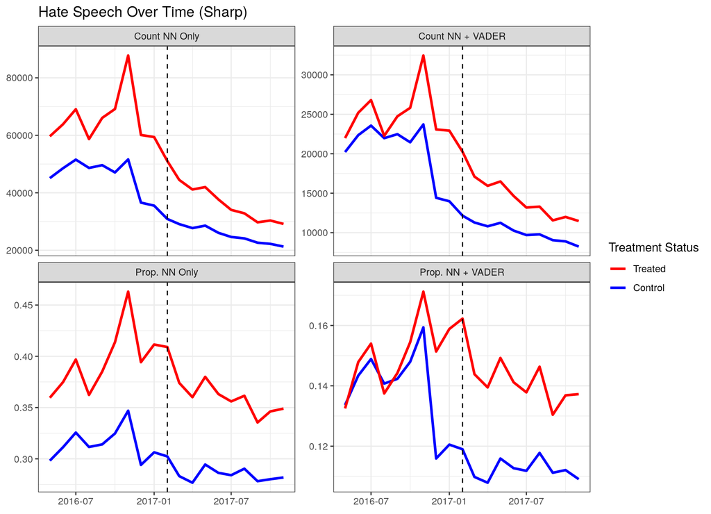

```r
authors <- read_csv("../data/authors_final_data.csv")

stat_names <- list(
  'mean_hate' = "Prop. NN + VADER",
  'mean_clas' = "Prop. NN Only",
  'cnt_hate' = "Count NN + VADER",
  'cnt_clas' = "Count NN Only"
)

stat_labeller <- function(variable, value){
  return(stat_names[value])
}

authors_final_sharp %>%
  author_agg_by_month() %>%
  ungroup() %>%
  mutate(date = ymd(date)) %>%
  filter(between(date, ymd("2016-05-01"), ymd("2017-11-01"))) %>%
  gather(stat, value, -date, -treated, -mean_sent) %>%
ggplot() +
  geom_line(aes(
    x = date,
    y = value,
    color = factor(treated),
    group = treated),
    size = 1.1
    ) +
  facet_wrap(vars(stat), scales = "free_y", labeller = stat_labeller) +
  geom_vline(xintercept = ymd("2017-02-01"), linetype = "dashed") +
  scale_color_manual(
    breaks = c("1", "0"),
    labels = c("0" = "Control", "1" = "Treated"),
    values = c("0" = "blue", "1" = "red"),
    name = "Treatment Status",
    ) +
  theme_bw() +
  labs(
    title = "Hate Speech Over Time (Sharp)"
  ) +
  theme(
    axis.title = element_blank()
  ) +
  ggsave("../plots/hs_sharp.png", width = 7, height = 5)
```

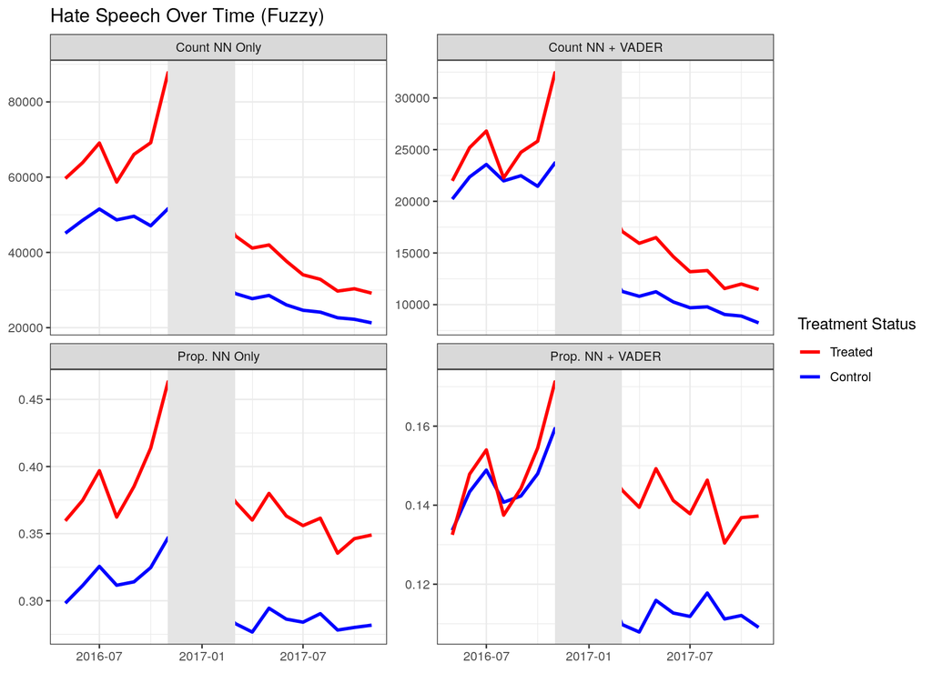

```r
authors_final_fuzzy %>%
  author_agg_by_month() %>%
  ungroup() %>%
  mutate(date = ymd(date)) %>%
  filter(between(date, ymd("2016-05-01"), ymd("2017-11-01"))) %>%
  gather(stat, value, -date, -treated, -mean_sent) %>%
ggplot() +
  geom_line(aes(
    x = date,
    y = value,
    color = factor(treated),
    group = treated),
    size = 1.1
    ) +
  facet_wrap(vars(stat), scales = "free_y", labeller = stat_labeller) +
  scale_color_manual(
    breaks = c("1", "0"),
    labels = c("0" = "Control", "1" = "Treated"),
    values = c("0" = "blue", "1" = "red"),
    name = "Treatment Status",
    ) +
  annotate("rect",
    xmin = ymd("2016-11-01"), xmax = ymd("2017-03-01"),
    ymin = -Inf, ymax = Inf,
    fill = "grey90"
    ) +
  theme_bw() +
  labs(
    title = "Hate Speech Over Time (Fuzzy)"
  ) +
  theme(
    axis.title = element_blank()
  ) +
  ggsave("../plots/hs_fuzzy.png", width = 7, height = 5)
```

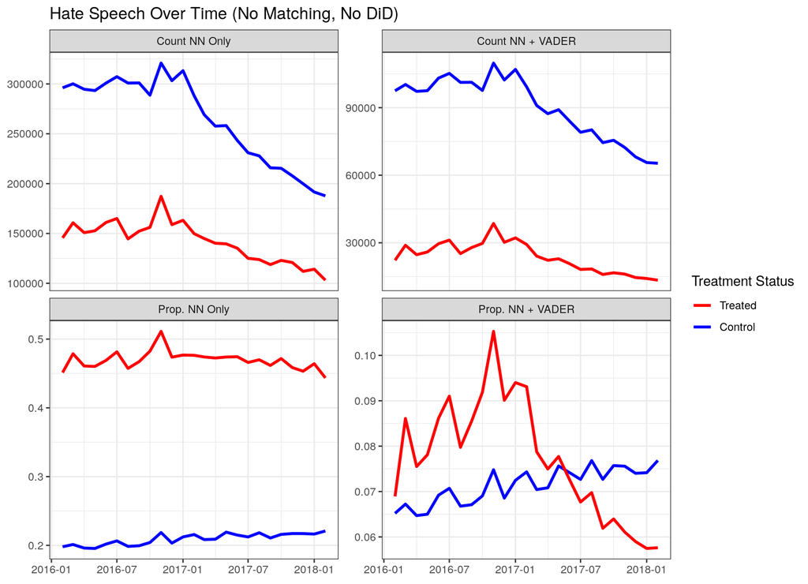

```r
authors %>%
  author_agg_by_month() %>%
  ungroup() %>%
  mutate(date = ymd(date)) %>%
  gather(stat, value, -date, -treated, -mean_sent) %>%
  ggplot() +
  geom_line(aes(
    x = date,
    y = value,
    color = factor(treated),
    group = treated),
    size = 1.1
    ) +
  facet_wrap(vars(stat), scales = "free_y", labeller = stat_labeller) +
  scale_color_manual(
    breaks = c("1", "0"),
    labels = c("0" = "Control", "1" = "Treated"),
    values = c("0" = "blue", "1" = "red"),
    name = "Treatment Status",
    ) +
  theme_bw() +
  labs(
    title = "Hate Speech Over Time (No Matching, No DiD)"
  ) +
  theme(
    axis.title = element_blank()
  ) +
  ggsave("../plots/hs_no_matching.png", width = 7, height = 5)
```